# Case_Study_Final

## Final Case Study

US Permanent Visa Analysis & Prediction

**Case Study: Perform analysis to identify different important factors that could impact the US permanent visa application**  
I will be using US permanent visa dataset and run various graph analysis on the selected features to see how each of them impact the outcome of the US permanent visa application.  
**Dataset:**

- Original dataset has been taken from https://www.kaggle.com/jboysen/us-perm-visas.
- In DSC 540, I have applied several data modification on this dataset by combining few columns and by normalizing the data in few columns.
- For this exercise I am going to use the final csv created out of my previous exercise.

```python
# Import necessary packages
import pandas as pd
import yellowbrick
import matplotlib.pyplot as plt
from matplotlib.gridspec import GridSpec
from yellowbrick.features import Rank2D
from yellowbrick.style import set_palette
from yellowbrick.features import ParallelCoordinates
import numpy as np
```

**Step 1: Load data into a dataframe**

```python
# Load data into article dataframe
addr1 = "case_study_data/us_perm_visas_final.csv"
raw_df = pd.read_csv(addr1, low_memory=False)
print("Shape of raw input:", raw_df.shape)
```

```
Shape of raw input: (374362, 17)
```

```python
# Get an idea about original dataset
print("The dimension of the table is: ", raw_df.shape)
# Display the data
print("\nTop 5 rows", raw_df.head(5))
# Print columns with None data
print("\nRows with missing data by column:\n", raw_df.isna().sum())
```

```
The dimension of the table is:  (374362, 17)

Top 5 rows      case_number case_status class_of_admission country_of_citizenship  \
0  A-07323-97014   Certified                J-1                ARMENIA
1  A-07332-99439      Denied                B-2                 POLAND
2  A-07333-99643   Certified               H-1B                  INDIA
3  A-07339-01930   Certified                B-2            SOUTH KOREA
4  A-07345-03565   Certified                L-1                 CANADA

  decision_date                employer_name  employer_num_employees  \
0    2012-02-01             NETSOFT USA INC.                     NaN
1    2011-12-21  PINNACLE ENVIRONEMNTAL CORP                     NaN
2    2011-12-01   SCHNABEL ENGINEERING, INC.                     NaN
3    2011-12-01      EBENEZER MISSION CHURCH                     NaN
4    2012-01-26   ALBANY INTERNATIONAL CORP.                     NaN

               employer_name.1 employer_state  \
0             NETSOFT USA INC.             NY
1  PINNACLE ENVIRONEMNTAL CORP             NY
2   SCHNABEL ENGINEERING, INC.             VA
3      EBENEZER MISSION CHURCH             NY
4   ALBANY INTERNATIONAL CORP.             NY

  foreign_worker_info_birth_country job_info_work_city job_info_work_state  \
0                               NaN           New York                  NY
1                               NaN           New York                  NY
2                               NaN        Lutherville                  MD
3                               NaN           Flushing                  NY
4                               NaN             Albany                  NY

                           pw_job_title_9089 pw_level_9089  \
0  Computer Software Engineers, Applications      Level II
1                           ASBESTOS HANDLER       Level I
2                             Civil Engineer       Level I
3                                 File Clerk      Level II
4                   Sales & Service Engineer      Level IV

                                pw_soc_title pw_amount_9089  \
0  Computer Software Engineers, Applications        75629.0
1        Hazardous Materials Removal Workers        37024.0
```

[output cut: 15 more lines]

```
country_of_citizenship                   59
decision_date                             0
employer_name                            12
employer_num_employees               135349
employer_name.1                          12
employer_state                           42
foreign_worker_info_birth_country    135300
job_info_work_city                      102
job_info_work_state                     103
pw_job_title_9089                       392
pw_level_9089                         27627
pw_soc_title                           2336
pw_amount_9089                         2216
pw_unit_of_pay_9089                    1572
dtype: int64
```

**Step 2: Feature & data selection - Select the features and rows meaningful for the goal**

```python
# Drop the rows with missing data for columns 'class_of_admission', 'country_of_citizenship',
# 'employer_state', 'pw_unit_of_pay_9089'
raw_df.dropna(axis=0, how = 'any', subset=['class_of_admission',
                                           'country_of_citizenship',
                                           'employer_state',
                                           'pw_unit_of_pay_9089'], inplace=True)
# Select few interesting columns
# .copy() would create a new DF
data=raw_df[['case_status',
         'class_of_admission',
         'country_of_citizenship',
         'employer_num_employees',
         'employer_state',
         'pw_level_9089',
         'decision_date']].copy()

# Modify the column names
data.columns = ['case_status', 'entry_visa', 'citizenship',
                'no_of_employees', 'state', 'job_level', 'year']

def getsalary(x):
    """This method will calculate the salary based on rate in column pw_unit_of_pay_9089"""
    if x[15].__class__ == str:
        salary=float(x[15].replace(',', ''))
    else:
        salary = x[15]

    # Get correct wage_unit value due to bad input data
    wage_unit = x[16]

    if salary > 15000:
        wage_unit='Year'
    elif x[16] == 'Year':
        if salary < 200:
            wage_unit='Hour'
        elif salary < 2500:
            wage_unit='Week'
        elif salary < 10000:
            wage_unit = 'Month'
    elif x[16] == 'Bi-Weekly':
        if salary < 100:
            wage_unit = 'Hour'
    elif x[16] == 'Week':
        if salary < 100:
            wage_unit='Hour'
    elif x[16] == 'Hour':
        if salary > 15000:
            wage_unit='Year'
        elif salary > 2000:
            wage_unit='Month'
        elif salary > 1000:
            wage_unit='Bi-Weekly'
        elif salary > 200:
            wage_unit='Week'

    # Get salary based on wage unit
    if wage_unit == 'Hour':
        return salary*52*40
    elif wage_unit == 'Week' or x[16] == 'wk':
        return salary*52
    elif wage_unit == 'Bi-Weekly' or x[16] == 'bi':
        return salary*26
    elif wage_unit == 'Month' or x[16] == 'mth':
        return salary*12
    else:
        if salary > 1000000:
            return salary/100
        return salary

# Get yearly salary on all rows
data['salary'] = raw_df.apply(getsalary, axis=1)
```

```python
# Select only data from 2014, 2015 & 2016 years for this analysis
data = data[data['year'] > '2013-12-31']

# Reset the index as we eliminated some rows
data = data.reset_index(drop=True)
```

```python
print("Dataset state after step 2 - feature and data selection\n")
# Get an idea about original dataset
print("The dimension of the table is: ", data.shape)
# Display the data
print("\nTop 5 rows", data.head(5))
# Print columns with None data
print("\nRows with missing data by column:\n", data.isna().sum())
```

```
Dataset state after step 2 - feature and data selection

The dimension of the table is:  (279365, 8)

Top 5 rows          case_status entry_visa  citizenship  no_of_employees          state  \
0  Certified-Expired       H-1B        INDIA              NaN  MASSACHUSETTS
1  Certified-Expired       H-1B        INDIA              NaN       ARKANSAS
2          Certified       H-1B        INDIA              NaN       NEW YORK
3  Certified-Expired       H-1B  SOUTH KOREA              NaN     CALIFORNIA
4          Certified       H-1B        INDIA              NaN      WISCONSIN

   job_level        year    salary
0   Level IV  2014-02-21  116542.4
1    Level I  2014-01-08   42973.0
2  Level III  2014-05-22  101629.0
3   Level II  2014-03-28   60445.0
4   Level IV  2014-05-28   92414.0

Rows with missing data by column:
 case_status            0
entry_visa             0
citizenship            0
no_of_employees    57167
state                  0
job_level          19805
year                   0
salary                 0
dtype: int64
```

**Step 3: Modify feature values to make it more suitable for analysis**

```python
# Modify data to get better analysis results

# Derive the year column with substring function of str
data['year'] = data['year'].apply(lambda x: int(x[0:4]))

# Convert job level to a numeric field as needed for different analysis algorithms
data = data.replace({'job_level': {'Level I': int(1),
                                   'Level II': int(2),
                                   'Level III': int(3),
                                   'Level IV': int(4)}})
```

```python
# Fill missing values for no_of_employees & salary using median of the column
def fill_na_median(data, inplace=True):
    """This method fills missing rows with median for that column"""
    return data.fillna(data.median(), inplace=inplace)

fill_na_median(data['salary'])
fill_na_median(data['no_of_employees'])

# Fill missing values for job_level using the most common value (Level II)
def fill_na_top_value(data, value, inplace=True):
    """This method fills missing rows with median for that column"""
    return data.fillna(value, inplace=inplace)

fill_na_top_value(data['job_level'], 2)
```

```python
# Derive the log transformed values for salary & no_of_employees
data['salary_log'] = data['salary'].apply(np.log1p)
data['no_of_employees_log'] = data['no_of_employees'].apply(np.log1p)
print("\nTop 5 rows after log transformation for salary & no_of_employees along with the original values\n",
      data[['salary', 'salary_log', 'no_of_employees', 'no_of_employees_log']].head(5))
```

```
Top 5 rows after log transformation for salary & no_of_employees along with the original values
      salary  salary_log  no_of_employees  no_of_employees_log
0  116542.4   11.666019           1634.0             7.399398
1   42973.0   10.668351           1634.0             7.399398
2  101629.0   11.529094           1634.0             7.399398
3   60445.0   11.009506           1634.0             7.399398
4   92414.0   11.434045           1634.0             7.399398
```

```python
print("Dataset state after step 3 - modifying some features and filling missing values\n")
# Get an idea about original dataset
print("The dimension of the table is: ", data.shape)
# Display the data
print("\nTop 5 rows", data.head(5))
# Print columns with None data
print("\nRows with missing data by column:\n", data.isna().sum())
```

```
Dataset state after step 3 - modifying some features and filling missing values

The dimension of the table is:  (279365, 10)

Top 5 rows          case_status entry_visa  citizenship  no_of_employees          state  \
0  Certified-Expired       H-1B        INDIA           1634.0  MASSACHUSETTS
1  Certified-Expired       H-1B        INDIA           1634.0       ARKANSAS
2          Certified       H-1B        INDIA           1634.0       NEW YORK
3  Certified-Expired       H-1B  SOUTH KOREA           1634.0     CALIFORNIA
4          Certified       H-1B        INDIA           1634.0      WISCONSIN

   job_level  year    salary  salary_log  no_of_employees_log
0        4.0  2014  116542.4   11.666019             7.399398
1        1.0  2014   42973.0   10.668351             7.399398
2        3.0  2014  101629.0   11.529094             7.399398
3        2.0  2014   60445.0   11.009506             7.399398
4        4.0  2014   92414.0   11.434045             7.399398

Rows with missing data by column:
 case_status            0
entry_visa             0
citizenship            0
no_of_employees        0
state                  0
job_level              0
year                   0
salary                 0
salary_log             0
no_of_employees_log    0
dtype: int64
```

**Step 4: Understand the type of variables in the dataset after all modifications**

```python
#what type of variables are in the table
print("\nDescribe Data")
print(data.describe())
print("\nSummarized Data")
print(data.describe(include=['O']))
```

```
Describe Data
       no_of_employees      job_level           year         salary  \
count     2.793650e+05  279365.000000  279365.000000  279365.000000
mean      1.992288e+04       2.551426    2015.146586   88646.609885
std       5.044350e+05       1.047190       0.811143   31965.935855
min       0.000000e+00       1.000000    2014.000000   10400.000000
25%       1.700000e+02       2.000000    2014.000000   71074.000000
50%       1.634000e+03       2.000000    2015.000000   88254.000000
75%       1.080000e+04       4.000000    2016.000000  106288.000000
max       2.635506e+08       4.000000    2016.000000  885666.000000

          salary_log  no_of_employees_log
count  279365.000000        279365.000000
mean       11.313593             7.199814
std         0.431814             2.754739
min         9.249657             0.000000
25%        11.171491             5.141664
50%        11.387986             7.399398
75%        11.573917             9.287394
max        13.694096            19.389756

Summarized Data
       case_status entry_visa citizenship   state
count       279365     279365      279365  279365
unique           4         54         197     112
top      Certified       H-1B       INDIA      CA
freq        147213     222234      159643   36454
```

**Step 5: Plot the histogram for numeric columns to understand the data**

```python
# Specify the features of interest
num_features = ['salary', 'no_of_employees', 'salary_log', 'no_of_employees_log', 'job_level', 'year']
xaxes = num_features
yaxes = ['Counts', 'Counts', 'Counts', 'Counts', 'Counts', 'Counts']
```

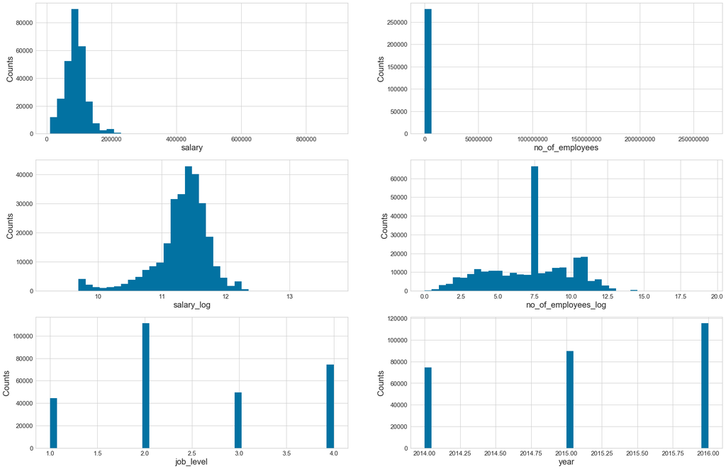

```python
#%matplotlib inline
# set up the figure size
plt.rcParams['figure.figsize'] = (30, 20)

# make subplots
fig, axes = plt.subplots(nrows = 3, ncols = 2)

# draw histograms
axes = axes.ravel()
for idx, ax in enumerate(axes):
    ax.hist(data[num_features[idx]].dropna(), bins=40)
    ax.set_xlabel(xaxes[idx], fontsize=20)
    ax.set_ylabel(yaxes[idx], fontsize=20)
    ax.tick_params(axis='both', labelsize=15)
    ax.ticklabel_format(useOffset=False, style='plain')

# Display the plot
plt.show()
```

**Step 6: Setup and plot bar charts for different features**

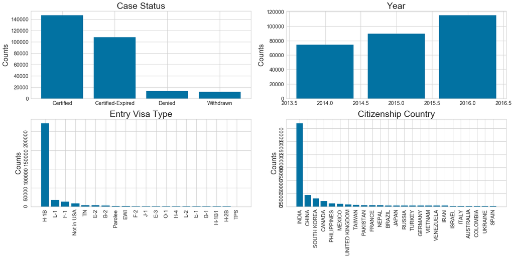

```python
#%matplotlib inline
# set up the figure size
plt.rcParams['figure.figsize'] = (20, 10)

# make subplots
fig = plt.figure(constrained_layout=True)
# Create grid of plots
gs = GridSpec(2,2, figure=fig)

# Derive different plot axes objects for bar chart plots
ax1 = fig.add_subplot(gs[0, 0])
ax2 = fig.add_subplot(gs[0, 1])
ax3 = fig.add_subplot(gs[-1, 0])
ax4 = fig.add_subplot(gs[-1, 1])

# make the data ready to feed into the visulizer
X_case_status = data.groupby('case_status').size().reset_index(name='Counts')['case_status']
Y_case_status = data.groupby('case_status').size().reset_index(name='Counts')['Counts']
# make the bar plot
ax1.bar(X_case_status, Y_case_status)
ax1.set_title('Case Status', fontsize=25)
ax1.set_ylabel('Counts', fontsize=20)
ax1.tick_params(axis='both', labelsize=15)

# make the data read to feed into the visulizer
X_year = data.groupby('year').size().reset_index(name='Counts')['year']
Y_year = data.groupby('year').size().reset_index(name='Counts')['Counts']
# make the bar plot
ax2.bar(X_year, Y_year)
ax2.set_title('Year', fontsize=25)
ax2.set_ylabel('Counts', fontsize=20)
ax2.tick_params(axis='both', labelsize=15)

# make the data read to feed into the visulizer
X_entry_visa = data.groupby('entry_visa').size().reset_index(name='Counts').nlargest(20, columns=['Counts'])['entry_visa']
Y_entry_visa = data.groupby('entry_visa').size().reset_index(name='Counts').nlargest(20, columns=['Counts'])['Counts']
# make the bar plot
ax3.bar(X_entry_visa, Y_entry_visa)
ax3.set_title('Entry Visa Type', fontsize=25)
ax3.set_ylabel('Counts', fontsize=20)
ax3.tick_params(axis='both', labelsize=15, labelrotation=90)

# make the data read to feed into the visulizer
X_citizenship = data.groupby('citizenship').size().reset_index(name='Counts').nlargest(25, columns=['Counts'])['citizenship']
Y_citizenship = data.groupby('citizenship').size().reset_index(name='Counts').nlargest(25, columns=['Counts'])['Counts']
# make the bar plot
ax4.bar(X_citizenship, Y_citizenship)
ax4.set_title('Citizenship Country', fontsize=25)
ax4.set_ylabel('Counts', fontsize=20)
ax4.tick_params(axis='both', labelsize=15, labelrotation=90)

plt.show()
```

**Step 7: Compare features using Pearson Ranking**

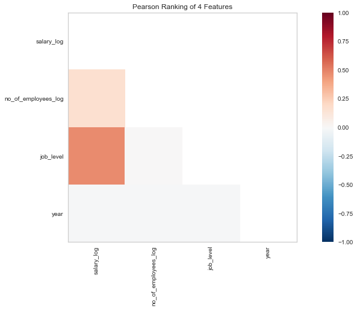

```python
#set up the figure size
#%matplotlib inline
plt.rcParams['figure.figsize'] = (15, 7)

# extract the numpy arrays from the data frame
num_features = ['salary_log', 'no_of_employees_log', 'job_level', 'year']
X = data[num_features].to_numpy()

# instantiate the visualizer with the Covariance ranking algorithm
visualizer = Rank2D(features=num_features, algorithm='pearson')
visualizer.fit(X)                # Fit the data to the visualizer
visualizer.transform(X)             # Transform the data
visualizer.poof(outpath="case_study_data/pearson1.png") # Draw/show/poof the data
plt.show()
```

**Step 8: Compare features againt case status using parallel coordinates**

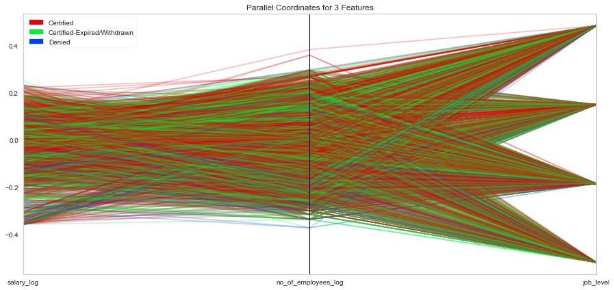

```python
#%matplotlib inline
#set up the figure size
plt.rcParams['figure.figsize'] = (15, 7)
plt.rcParams['font.size'] = 50

# Set palette color
set_palette('sns_bright')

# Specify the features of interest and the classes of the target
classes = ['Denied', 'Certified-Expired/Withdrawn', 'Certified']
num_features = ['salary_log', 'no_of_employees_log', 'job_level']

# copy data to a new dataframe and transform case_status to numeric
data_norm = data.copy().replace({'case_status':{'Certified': float(1),
                                    'Certified-Expired': float(0.5),
                                    'Withdrawn': float(0.5),
                                    'Denied': float(0)}})
# normalize data to 0-1 range
for feature in num_features:
    data_norm[feature] = (data[feature] - data[feature].mean()) / (
                          data[feature].max() - data[feature].min())

# Extract the numpy arrays from the data frame
X = data_norm[num_features].to_numpy()
y = data_norm.case_status.to_numpy()

# Instantiate the visualizer
# Used options sample & shuffle to get speader plot, otherwise fitting would take more time.
visualizer = ParallelCoordinates(classes=classes, features=num_features,
                                 sample=0.02, shuffle=True)

visualizer.fit(X, y)                              # Fit the data to the visualizer
visualizer.transform(X)                           # Transform the data
visualizer.poof(outpath="case_study_data/pcords2.png") # Draw/show/poof the data
plt.show()
```

**Step 9: Compare visa counts using stacked bar charts for several features**